# Modelo Multiplicativo

Sergio Martín Buzzi

17/11/2021

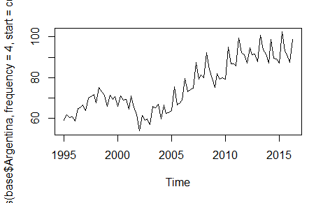

#### 1) Transformacion

- La variabilidad aumenta en la ultima fase de tiempo, podriamos tranformar, que transformacion hacemos?. Si la varainza es problematica generalmente hacemos log().
- Ademas tomamos log pq es una serie acumulativa. La del PBI.

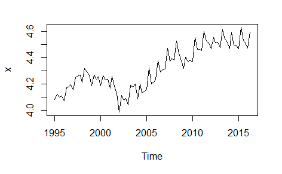

- Vemos que parece imperceptible, pero se logra achicar los ultimos picos, y se espera que esto impacte en los correlogramas en la parte de heterocedasticidad que quede mas lindo.
- Parecen repetirse cosas, vemos componenete estacional o ciclica.

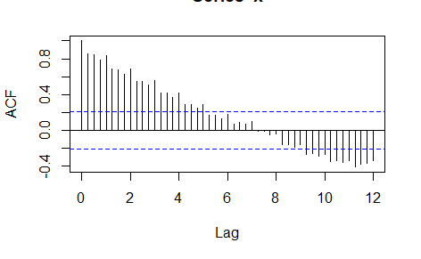

```r
acf(x, lag.max=48)
```

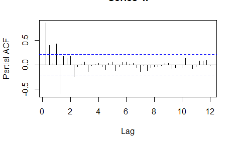

```r
pacf(x, lag.max=48)
```

Ahora vemos los correlogramas: FAS: decaimiento lento/ suave. Hay raiz unitaria o no? Si es muy lento es porque hay raiz unitaria, entonces que pasa?. En el lag 20 recien se mete adentro de las barrras, es medio mucho, debe haber raiz unitaria.

- Vemos decaimiento lento y piquitos cada 4, esto salta porque seguramente hay raiz unitaria estacional. Si fuese raiz unitaria simple, caeria mucho mas rapido.

De a 4 el decaimiento es lento y los del medio no muy alejados, raiz unitaria simple.

De a 1 decaimiento rapido exepto el 4 que es mas largo, raiz unitaria estacional. Estacional sola lento cada 4.

O pueden estar ambas.

Alguna de las dos esta presentes.

Cuando todo cae lento pueden estar ambas presentes.

Simple: hoy menos el trimestre pasado. Estacionaria: hoy menor el mismo trimestre el año pasado.

FAP: decaimiento suave.

El modelo multiplicativo generaliza los modelos ARIMA por medio de la inclusión de polinomios de retardo estacionales. También se pueden tomar diferencias estacionales para eliminar las raíces unitarias esacionales. Dichos modelos se pueden representar como $arma(p,d,q)\times ARMA_s(P,D,Q)$, o bien:
$$\Phi_P(L^s)\phi_p(L)(1-L^s)^D(1-L)^dx_t=\mu + \Theta_Q(L^s)\theta_q(L) \varepsilon_t$$

Apliquemos Box & Jenkins

```r
fit1
```

```
Call:
arima(x = x, order = c(0, 0, 0), seasonal = c(order = c(0, 1, 0), period = 4),
    method = "ML")


sigma^2 estimated as 0.004418:  log likelihood = 105.96,  aic = -209.91
```

seasonal=c(order=c(0,1,0) agregamos que queremos un sarima. (P,D,Q). D=1, 1 sola diferencia estacional.

period=4: periodicidad trimestral.

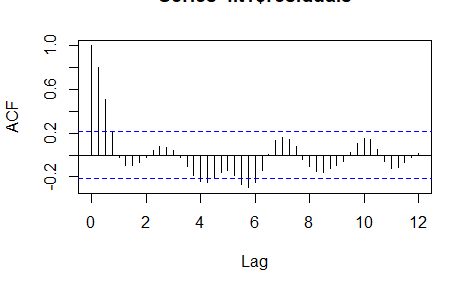

```r
acf(fit1$residuals, lag.max=48)
```

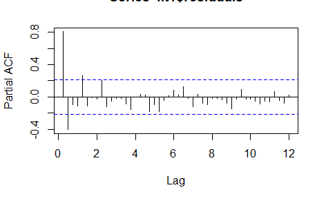

```r
pacf(fit1$residuals, lag.max=48)
```

FAS: Con diferencia estacional, desaparecen picos Se escapan barras consecutivas, es marcado, faltaria algo a priori. Raiz unitaria estacional estaba presente. Pero quiza podria hacer falta incluir para salvar una raiz unitaria simple.

Una alternativa es tomar también primera diferencia simple

```r
fit2
```

```
Call:
arima(x = x, order = c(0, 1, 0), seasonal = c(order = c(0, 1, 0), period = 4),
    method = "ML")


sigma^2 estimated as 0.001543:  log likelihood = 147.28,  aic = -292.55
```

Tomamos primera difererencia simple y vemos que ocurre:

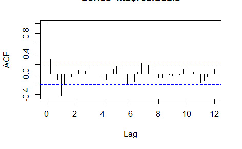

```r
acf(fit2$residuals, lag.max=48)
```

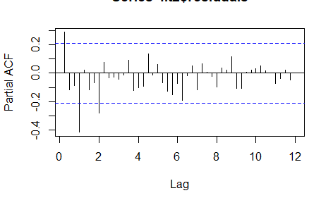

```r
pacf(fit2$residuals, lag.max=48)
```

FAS: Se ve que podria haber un MA(1) o MA(1) estacional. Decaimiento abrupto en 1 y en 4. Si quedara una raiz unitaria, cada 4 se escaparia. Es como que tenemos un retardo estacional significativo.

FAP: 1,4,8 caen fuera de las barras. Si quiero meter un solo componente veo mas claro el abrupto en la parte del MA, no los AR, que cae mas suavemente (lento).

**El siempre mete primero la parte estacional.** Va por la parte estacional del MA(1), componente SMA(1).

# Lo incluimos

```r
fit3
```

```
Call:
arima(x = x, order = c(0, 1, 0), seasonal = c(order = c(0, 1, 1), period = 4),
    method = "ML")

Coefficients:
         sma1
      -0.6378
s.e.   0.0993

sigma^2 estimated as 0.001097:  log likelihood = 160.04,  aic = -316.09
```

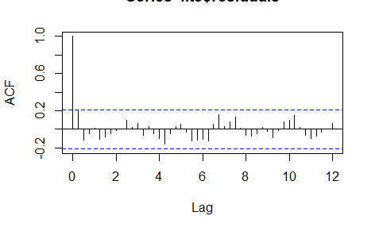

```r
acf(fit3$residuals, lag.max=48)
```

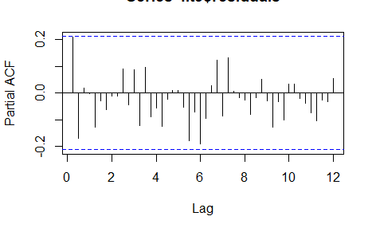

```r
pacf(fit3$residuals, lag.max=48)
```

FAS: El 0 no lo leemos y queda todo adentro

FAP:

Llegamos a correlograma limpio, sin correlacion en los residuos!. Ya tenemos el primer candidato, pordemos seguir probando otros modelos.

### Hacemos prueba para ver como queda LJUNG-BOX:

Como que queda autocorrelacion en los primeros ordenes. Vemos correlograma, y vemos que esta al limite. Que pasaria si le ponemos componente AR(1).

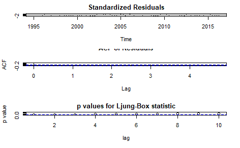

Los primeros no cumplen del todo.

## Agregamos componente AR(1):

```r
fit3b
```

```
Call:
arima(x = x, order = c(1, 1, 0), seasonal = c(order = c(0, 1, 1), period = 4),
    method = "ML")

Coefficients:
         ar1     sma1
      0.2373  -0.5973
s.e.  0.1112   0.1012

sigma^2 estimated as 0.001042:  log likelihood = 162.25,  aic = -318.5
```

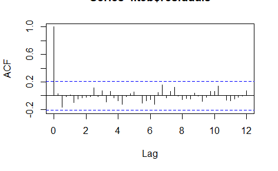

```r
acf(fit3b$residuals, lag.max=48)
```

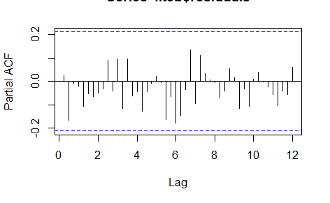

```r
pacf(fit3b$residuals, lag.max=48)
```

Vemos que cumple mucho mejor.